# Example Workflow for Single-Cell Annotation with easybio

[cw](https://cying.org)

2026-10-07

## Introduction

This vignette demonstrates the powerful and intuitive workflow for single-cell RNA-seq annotation provided by the `easybio` package. The process is designed to combine the speed of automated database matching with the reliability of interactive verification and manual curation.

The core workflow follows three logical steps:

1. **Automated Annotation**: Use `match_ref()` to quickly get a list of potential cell types for each cluster based on its marker genes.
2. **Verification & Exploration**: Interactively investigate the automated results using `check_marker()` and `plot_seurat_dot()` to build confidence in the annotations. This step helps answer two critical questions:
   - “**Why** was this annotation made?” (Which of my genes matched the database?)
   - “Is this annotation **correct**?” (Are the canonical markers for this cell type expressed in my cluster?)
3. **Final Curation**: Based on the evidence gathered, use `finsert()` to assign the final, high-confidence cell type labels.

You can also view the R script for this workflow by running: `file.show(system.file(package = 'easybio', 'example-single-cell.R'))`

## Setup

First, let’s load the necessary libraries and the example marker data included with `easybio`. This data is derived from the 10x Genomics 3k PBMC dataset.

```r
litedown::reactor(warning = FALSE) # vignette setting

library(easybio)
library(Seurat)
library(data.table)

# The pbmc.markers dataset is included in easybio
head(pbmc.markers)
```

|  | p_val | avg_log2FC | pct.1 | pct.2 | p_val_adj | cluster | gene |
| --- | --- | --- | --- | --- | --- | --- | --- |
| RPS12 | 0 | 0.739 | 1.000 | 0.991 | 0 | 0 | RPS12 |
| RPS6 | 0 | 0.693 | 1.000 | 0.995 | 0 | 0 | RPS6 |
| RPS27 | 0 | 0.737 | 0.999 | 0.992 | 0 | 0 | RPS27 |
| RPL32 | 0 | 0.627 | 0.999 | 0.995 | 0 | 0 | RPL32 |
| RPS14 | 0 | 0.634 | 1.000 | 0.994 | 0 | 0 | RPS14 |
| RPS25 | 0 | 0.769 | 0.997 | 0.975 | 0 | 0 | RPS25 |

## Step 1: Automated Annotation with `match_ref`

We begin by feeding the cluster markers (from `Seurat::FindAllMarkers`) into `match_ref()`. This function compares our markers against the CellMarker 3.0 database and returns a ranked list of potential cell types for each cluster.

### Bounding the search to the right tissue

By default `match_ref()` searches the whole database, which mixes every organ: for PBMC data that puts hepatocytes and alveolar cells in the same candidate list as monocytes. Each database entry carries two labels that can narrow it:

- `tissue_class`, the organ or system the entry came from (`Blood`, `Bone marrow`, `Lung`, …), and
- `tissue_type`, the sample the original study described (`Peripheral blood`, `Peripheral blood mononuclear cell`, `Whole blood`, …).

They are two labels on an entry rather than a hierarchy — one `tissue_type` can be listed under several classes — and `match_ref()` combines them with AND. Bounding `tissue_class` is the useful move here; bounding `tissue_type` as well removes evidence instead of correcting for anything: restricted to `"Peripheral blood"` alone, cluster 8’s platelet markers keep only a fraction of their support and it comes out as a dendritic cell instead. Our sample is peripheral blood mononuclear cells, so blood and bone marrow, where the monocytes and dendritic cells circulating in it are made, is the natural bound:

```r
# the organ-level classes, and what one of them actually holds
length(available_tissue_class("Human"))
```

```
#> [1] 87
```

```r
available_tissue_type("Human", tissue_class = "Blood")
```

```
#>  [1] "Peripheral blood"                  "Peripheral blood mononuclear cell"
#>  [3] "Blood"                             "Umbilical cord blood"
#>  [5] "Lymph"                             "Serum"
#>  [7] "Artery"                            "Whole blood"
#>  [9] "Plasma"                            "Thymus"
```

```r
marker_matched <- match_ref(
  marker = pbmc.markers, n = 50, spc = "Human",
  tissue_class = c("Blood", "Bone marrow")
)

# Let's look at the top 2 potential cell types for each cluster
marker_matched[, head(.SD, 2), by = cluster]
```

| cluster | cell_name | uniqueN | N | ordered_symbol | orderN | pct_with |
| --- | --- | --- | --- | --- | --- | --- |
| 0 | T cell | 30 | 80 | CCR7,LEF1,CD5,MAL,LRRN3,NELL2,… | 9,8,6,5,4,4,… | 0.447,0.342,0.127,0.268,0.038,0.158,… |
| 0 | CD4+ T cell | 21 | 81 | MAL,TSHZ2,LEF1,CCR7,TRABD2A,FHIT,… | 8,8,7,6,6,5,… | 0.268,0.094,0.342,0.447,0.199,0.200,… |
| 1 | Monocyte | 31 | 178 | CD14,S100A9,S100A8,CREB5,S100A12,NRG1,… | 51,13,12, 9, 9, 8,… | 0.667,0.996,0.975,0.031,0.277,0.146,… |
| 1 | Myeloid cell | 16 | 43 | CD14,S100A8,S100A9,CD93,S100A12,CLEC4E,… | 6,6,6,4,4,3,… | 0.667,0.975,0.996,0.077,0.277,0.150,… |
| 2 | T cell | 21 | 50 | GPR171,CD2,TNFRSF25,CD40LG,AQP3,CCR6,… | 9,6,6,5,2,2,… | 0.132,0.651,0.162,0.263,0.420,0.063,… |
| ⋮ | ⋮ | ⋮ | ⋮ | ⋮ | ⋮ | ⋮ |
| 6 | T cell | 9 | 27 | PRF1,FGFBP2,SPON2,GNLY,GZMB,KLRF1,… | 6,4,4,3,3,3,… | 0.948,0.877,0.729,0.961,0.961,0.271,… |
| 7 | Dendritic cell | 24 | 102 | FCER1A,CLEC4C,CLEC10A,ENHO,FLT3,LILRA4,… | 15, 9, 8, 7, 7, 7,… | 0.812,0.188,0.688,0.438,0.125,0.156,… |
| 7 | Conventional dendritic cell | 21 | 101 | FCER1A,CD1E,ENHO,PKIB,CLEC10A,CLIC2,… | 11,10, 9, 9, 8, 8,… | 0.812,0.062,0.438,0.188,0.688,0.281,… |
| 8 | Platelet | 34 | 111 | PPBP,PF4,GP9,TUBB1,ITGA2B,SPARC,… | 13, 9, 6, 5, 4, 4,… | 1.000,1.000,0.923,0.846,0.846,1.000,… |
| 8 | Conventional dendritic cell | 15 | 43 | GP1BA,TMEM40,AP001189.4,CLU,GNG11,GP9,… | 4,4,3,3,3,3,… | 0.615,0.769,0.846,0.846,1.000,0.923,… |

The output table gives us `uniqueN` (the number of unique matching markers) and `N` (the total number of matches), which helps rank the potential annotations.

We can create a quick preliminary annotation by taking the top hit for each cluster.

```r
cl2cell_auto <- marker_matched[, head(.SD, 1), by = .(cluster)]
cl2cell_auto <- setNames(cl2cell_auto[["cell_name"]], cl2cell_auto[["cluster"]])
print("Initial automated annotation:")
```

```
#> [1] "Initial automated annotation:"
```

```r
cl2cell_auto
```

```
#>                     0                     1                     2
#>              "T cell"            "Monocyte"              "T cell"
#>                     3                     4                     5
#>              "B cell"              "T cell"            "Monocyte"
#>                     6                     7                     8
#> "Natural killer cell"      "Dendritic cell"            "Platelet"
```

We can also get a global view of all possible annotations using `plot_possible_cell`.

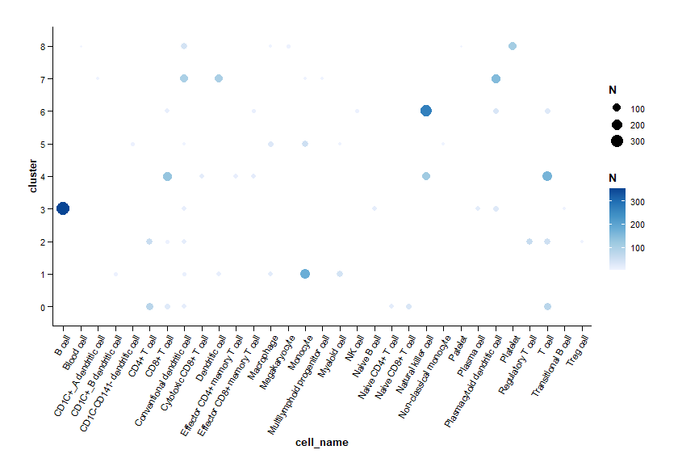

```r
plot_possible_cell(marker_matched[, head(.SD), by = .(cluster)], min_unique_n = 2)
```

The same view can be coloured by how well the evidence is actually detected. With `value = "pct"` the fill shows the share of each candidate’s matched markers whose detection rate reaches `min_pct`, which is the quickest way to spot annotations that rest on barely expressed genes.

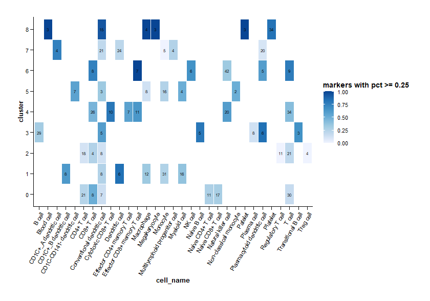

```r
plot_possible_cell(marker_matched[, head(.SD), by = .(cluster)], min_unique_n = 2, value = "pct")
```

## Step 2: Verification and Exploration

This is the most critical step. Instead of blindly trusting the automated result, we use `easybio`’s tools to verify it.

### Answering “Why was this annotation made?”

To see the evidence behind an annotation, we use `check_marker()` with `cis = TRUE`. This shows us which of **our own marker genes** from our data matched the database for a given annotation.

```r
# Let's investigate clusters 1, 5, and 7
local_evidence <- check_marker(marker_matched, cl = c(1, 5, 7), top_cell_n = 2, cis = TRUE)
print(local_evidence)
```

```
#> $Monocyte
#>  [1] "CD14"      "S100A9"    "S100A8"    "CREB5"     "S100A12"   "NRG1"
#>  [7] "ASGR1"     "FCAR"      "MS4A6A"    "ALDH1A1"   "CLEC4E"    "LINC00937"
#> [13] "MITF"      "CCDC149"   "CD93"      "FCGR1A"    "FOLR3"     "HGF"
#> [19] "MGST1"     "CYP27A1"   "DYSF"      "LGALS2"    "LIN7A"     "MPO"
#> [25] "QPCT"      "RNASE2"    "TMEM150B"  "CCL2"      "ELANE"     "PLA2G7"
#> [31] "SIRPA"
#>
#> $`Myeloid cell`
#>  [1] "CD14"    "S100A8"  "S100A9"  "CD93"    "S100A12" "CLEC4E"  "MS4A6A"
#>  [8] "LGALS2"  "MPO"     "ALDH1A1" "CCDC149" "CYP27A1" "ELANE"   "FCGR1A"
#> [15] "MGST1"   "PLA2G7"
#>
#> $Monocyte
#>  [1] "MS4A7"    "FCGR3B"   "CDKN1C"   "LYPD2"    "C1QA"     "CASP5"
#>  [7] "SFTPD"    "C1QB"     "GPR20"    "HES4"     "SMPDL3A"  "ARHGAP29"
#> [13] "CKB"      "CYP4F22"  "PPP1R17"  "VMO1"
#>
#> $Macrophage
#> [1] "C1QA"    "C1QB"    "C3"      "FCGR3B"  "KCNMA1"  "MS4A7"   "MYO10"
#> [8] "SMPDL3A"
#>
#> $`Dendritic cell`
#>  [1] "FCER1A"   "CLEC4C"   "CLEC10A"  "ENHO"     "FLT3"     "LILRA4"
#>  [7] "TNFRSF21" "CLIC2"    "IL1R2"    "P2RY6"    "CD1E"     "GAS6"
#> [13] "SERPINF1" "AXL"      "DNASE1L3" "LAMP5"    "LRRC26"   "PROC"
#> [19] "SCT"      "TIFAB"    "CRYM"     "PMP22"    "SEZ6L"    "SMPD3"
#>
#> $`Conventional dendritic cell`
#>  [1] "FCER1A"   "CD1E"     "ENHO"     "PKIB"     "CLEC10A"  "CLIC2"
#>  [7] "IL1R2"    "FBLN2"    "FLT3"     "IDO1"     "P2RY6"    "AXL"
#> [13] "DNASE1L3" "SERPINF2" "GAS6"     "GEM"      "GFRA2"    "PLS3"
#> [19] "PMP22"    "SDS"      "SEZ6L"
#>
```

### Answering “Is this annotation correct?”

To validate an annotation, we use `check_marker()` with `cis = FALSE` (the default). This fetches the **canonical markers** for the suggested cell type from the database. We can then check if these well-known markers are expressed in our cluster.

```r
canonical_markers <- check_marker(marker_matched, cl = c(1, 5, 7), top_cell_n = 2, cis = FALSE)
print(canonical_markers)
```

```
#> $Monocyte
#>  [1] "CD14"     "FCN1"     "LYZ"      "SLC11A1"  "VCAN"     "CD300E"
#>  [7] "IRAK3"    "CLEC12A"  "SERPINA1" "FCGR3A"
#>
#> $`Myeloid cell`
#>  [1] "LYZ"    "CD68"   "FCN1"   "CD14"   "S100A9" "S100A8" "SULF2"  "CD86"
#>  [9] "KLF4"   "FPR1"
#>
#> $Macrophage
#>  [1] "CD68"    "CD163"   "C1QA"    "C1QB"    "CD14"    "C1QC"    "MRC1"
#>  [8] "SLCO2B1" "CXCL2"   "PHLDA1"
#>
#> $`Dendritic cell`
#>  [1] "FCER1A"  "CD1C"    "CLEC4C"  "CLEC10A" "PLD4"    "CST3"    "NEGR1"
#>  [8] "ENHO"    "FLT3"    "SLC41A2"
#>
#> $`Conventional dendritic cell`
#>  [1] "CD1C"   "FCER1A" "NDRG2"  "CD1E"   "PKIB"   "ENHO"   "PDLIM1" "CYP2S1"
#>  [9] "CCSER1" "COL9A2"
#>
```

### Visual Confirmation with `plot_seurat_dot`

The best way to check marker expression is visually. `plot_seurat_dot` is designed to work seamlessly with `check_marker`.

The entire pipeline from annotation to visualization can be done in a single, elegant pipe:

```r
# For this example to be runnable, we need a Seurat object.
# We'll create a minimal one. In your real workflow, you would use your own srt object.
marker_genes <- unique(pbmc.markers$gene)
counts <- matrix(
  abs(rnorm(length(marker_genes) * 50, mean = 1, sd = 2)),
  nrow = length(marker_genes),
  ncol = 50
)
rownames(counts) <- marker_genes
colnames(counts) <- paste0("cell_", 1:50)
srt <- CreateSeuratObject(counts = counts)
# Assign clusters that match the pbmc.markers data
srt$seurat_clusters <- sample(0:8, 50, replace = TRUE)
Idents(srt) <- "seurat_clusters"


# Now, let's plot the evidence for clusters 1, 5, and 7
match_ref(marker = pbmc.markers, n = 50, spc = "Human") |>
  check_marker(cl = c(1, 5, 7), top_cell_n = 2, cis = TRUE) |>
  plot_seurat_dot(srt = srt)
```

[output not shown]

## Step 3: Final Manual Curation

```r
# Based on our exploration, we finalize the annotations
cl2cell_final <- finsert(
  list(
    c(3) ~ "B cell",
    c(8) ~ "Megakaryocyte",
    c(7) ~ "DC",
    c(1, 5) ~ "Monocyte",
    c(0, 2, 4) ~ "Naive CD8+ T cell",
    c(6) ~ "Natural killer cell"
  ),
  len = 9 # Ensure vector length covers all clusters (0-8)
)
print("Final curated annotation:")
```

```
#> [1] "Final curated annotation:"
```

```r
cl2cell_final
```

```
#>                     0                     1                     2
#>   "Naive CD8+ T cell"            "Monocyte"   "Naive CD8+ T cell"
#>                     3                     4                     5
#>              "B cell"   "Naive CD8+ T cell"            "Monocyte"
#>                     6                     7                     8
#> "Natural killer cell"                  "DC"       "Megakaryocyte"
```

This `cl2cell_final` vector can now be added to your Seurat object’s metadata for downstream analysis and plotting.

## Using a Custom Marker Database

For specialized analyses, such as focusing on a specific tissue, working with a non-model organism, or using a proprietary list of markers, you can provide your own custom reference to `match_ref`.

The reference must be a `data.frame` (or `data.table`) with at least two columns: `cell_name` and `marker`. The easiest way to create this is from a named list.

**Step 1: Create a named list of your custom markers.**

```r
custom_ref_list <- list(
  "T-cell" = c("CD3D", "CD3E", "CD3G"),
  "B-cell" = c("CD79A", "MS4A1"),
  "Myeloid" = c("LYZ", "CST3", "AIF1")
)
print(custom_ref_list)
```

```
#> $`T-cell`
#> [1] "CD3D" "CD3E" "CD3G"
#>
#> $`B-cell`
#> [1] "CD79A" "MS4A1"
#>
#> $Myeloid
#> [1] "LYZ"  "CST3" "AIF1"
#>
```

**Step 2: Convert the list to the required data.frame format.** `easybio` provides the `list2dt` helper function for this.

```r
custom_ref_df <- list2dt(custom_ref_list, col_names = c("cell_name", "marker"))
head(custom_ref_df)
```

| cell_name | marker |
| --- | --- |
| T-cell | CD3D |
| T-cell | CD3E |
| T-cell | CD3G |
| B-cell | CD79A |
| B-cell | MS4A1 |
| Myeloid | LYZ |

**Step 3: Run `match_ref` with the `ref` parameter.** When `ref` is provided, the function ignores the `spc`, `tissue_class`, and `tissue_type` parameters for matching.

```r
marker_custom <- match_ref(
  marker = pbmc.markers,
  n = 50,
  ref = custom_ref_df
)
# Note that the cell_name column now contains our custom cell types
marker_custom[, head(.SD, 2), by = cluster]
```

| cluster | cell_name | uniqueN | N | ordered_symbol | orderN | pct_with |
| --- | --- | --- | --- | --- | --- | --- |
| 3 | B-cell | 2 | 2 | CD79A,MS4A1 | 1,1 | 0.936,0.855 |

## Additional Utilities

`easybio` also provides functions for direct queries.

### `get_marker()`

Directly retrieve markers for any cell type of interest.

```r
get_marker(spc = "Human", cell = c("Monocyte", "Neutrophil"), number = 5, min_count = 1)
```

```
#> $Monocyte
#> [1] "FCN1"   "CD14"   "S100A8" "S100A9" "LILRA5"
#>
#> $Neutrophil
#> [1] "S100A9" "S100A8" "FCGR3B" "CSF3R"  "CXCL8"
#>
```

### `plot_marker_distribution()`

Check the distribution of a specific marker across all cell types and tissues in the database.

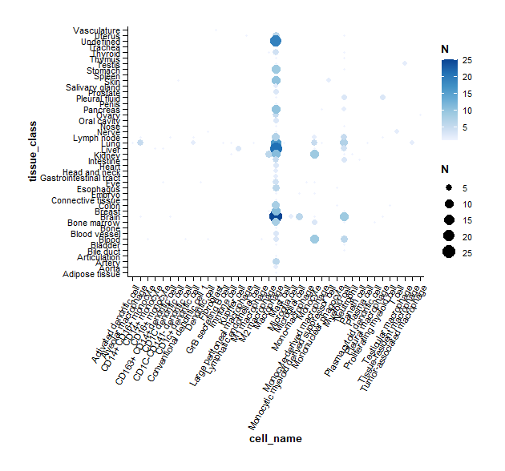

```r
plot_marker_distribution(mkr = "CD68")
```